# 2.Genrazioni di realizzazioni di variabili casuali

NikolayNikolaev

2023-10-24

2. Generazioni di realizzazioni di variabili casuali

Generare delle realizzazioni da variabili casuali signi ca produrre al calcolatore valori che provengono da una determinata distribuzione di probabilita (densita) di una variabile casuale discreta, continua, unidimensionale o multidimensionale. In pratica si simulano n-uple campionarie da popolazioni le cui variabile casuale sottostanti hanno un’assegnata distribuzione.

La generazione di variabile casuale avviene in genere al calcolatore, mediante l’implementazione di algoritmi iterativi che impiegano una serie di numeri pseudo-casuali. Una volta ottenute le determinazioni si impiegano alcuni test empirici come ad esempio la valutazione della rappresentazione gra ca della distribuzione di frequenza simulata, ovvero il controllo dei momenti (media, varianza, ecc.) e degli altri valori caratteristici delle determinazioni simulate (mediana, curtosi ecc.) che devono risultare vicini ai momenti teorici e alle caratteristiche note della distribuzione della variabile casuale di riferimento. La letteratura sulla generazione di variabile casuale e molto vasta, essenzialmente di tipo informatico. I metodi di generazione si suddividono in metodi Metodi Generali Esatti che comprendono il metodo della Trasformata Inversa e il Metodo di Accettazione/Ri uto ed Metodi ad hoc per speci che distribuzioni. Per alcuni dettagli si rimanda a Mecatti et al. (2008). L’algoritmo che si utilizza per produrre queste determinazioni in generale deve avere le seguenti caratteristiche:

- Esattezza. Un algoritmo per generare una variabile casuale e detto esatto se produce valori che hanno esattamente la distribuzione di probabilit a pre ssata; altrimenti, si parla di algoritmi approssimati. In passato la ricerca si e concentrata sullo sviluppo di metodi approssimati che in genere risultano meno costosi a livello computazionale dei metodi esatti. Attualmente, al crescere della potenza computazionale, disponiamo di metodi esatti per generare dalle variabile casuale piu note. Tuttavia, nella pratica, puo comunque essere conveniente, per motivi di economicita, utilizzare un metodo approssimato in luogo di un metodo esatto.
- Ecienza. Con riferimento ad un algoritmo, si parla di ecienza sia sotto il pro lo dello spazio di memoria sia sotto quello dei tempi di esecuzione necessari per ottenere l’output. Tali considerazioni, di evidente portata pratica oltre che teorica, intervengono ad esempio nella scelta fra due algoritmi esatti per generare dalla medesima variabile casuale.

Semplicita. Con riferimento ad un algoritmo, si parla di complessita sia sotto il pro lo concettuale sia dal punto di vista dell’implementazione (codi ca, ricerca e correzione degli errori ecc.). Come in ogni attivita umana, la semplicita e, anche in questo ambito, un criterio di buon senso altamente apprezzabile. Occorre pertanto valutare se l’eventuale guadagno di ecienza e tale da compensare l’aumento di complessita dell’algoritmo e dunque il maggiore sforzo di comprensione e implementazione del metodo.

Robustezza. Con riferimento ad un algoritmo, la robustezza e intesa come capacita di risolvere grandi classi di problemi piuttosto che casi particolari. Nell’ambito della generazione di variabile casuale esistono metodi generali, applicabili cioe a qualunque variabile casuale e dunque robusti, e metodi che viceversa risultano ecienti solo se applicati a particolari variabile casuale mentre falliscono per la generazione da altre variabile casuali.

Sulla base di tali osservazioni e senza pretese di esaustivita su un argomento tutt’ora oggetto di ricerca e comunque ben oltre gli obiettivi di questo corso, saranno qui richiamate alcune note distribuzioni di densita e di probabilita le cui realizzazioni saranno ottenute con le funzioni native dell’ambiente R (R Core Team, 2020).

### 1.4.1 Variabile casuale di Gauss

Sia X la variabile casuale continua Normale (o di Gauss) nel seguito indicata con la seguente notazione compatta $X \sim N(\mu, \sigma^2)$ e caratterizzata dai parametri $\mu \in \mathcal{R}$ e $\sigma \in \mathcal{R^+}$. Questa distribuzione e particolarmente utile dato che il teorema del limite centrale stabilisce, con relative non troppo stringenti assunzioni, che la somma (convoluzione) di molte variabili casuali indipendenti e identicamente distribuite, ha una distribuzione normale, indipendentemente della distribuzione delle singole variabili causali. La funzione di densita e la seguente:

$$f(x)= \frac{1}{\sigma \sqrt{2.\pi}}
exp[\\frac{1}{2 \sigma^2}(x-\mu)^2]$$
- $-\infty < x < \infty$

dove $\mu$ e $\sigma>0$ sono i parametri e $\pi$ e la costante matematica 3.1416…. . Ai fini della generazione da $X$ si sfruttano le seguenti osservazioni basate su altrettante proprieta della Normale: 1. Sia $Z \sim N(0,1)$, si ha $Z.\sigma + \mu = X$ 2. Pertanto e’ sufficiente avere un metodo che generi determinazioni da $\Z \sim N(0,1)$ ovvero dalla distribuzione Normale Standard per ottenere, mediante semplice trasformazione lineare $Z.\sigma + \mu = X$, , determinazioni da una qualunque variabile casuale appartenente alla famiglia $N(\mu, \sigma^2)$

3. Date n variabile casuali Normali indipendenti
   $$X_i \sim N(\mu_i, \sigma_i^2)$$

con $i=1...n$ la variabile casuale:
$$Y = \sum_{i=1}^n X_i$$

ha la seguente distribuzione

$Y \sim N(\sum_{i=1}^n \mu_i; \sum_{i=1}^n \sigma_i^2)$

Una variabile casaule continua Z assume una distribuzione normale standard se la funzione di densita e la seguente

$f(z)= \frac{1}{\sqrt{2\pi}} exp(-\frac{1}{2}z^2)$

e si scrive $Z \sim N(0,1)$. Si noti che la seguente costante $\frac{1}{\sqrt{2\pi}}$ e chiamata costante di normalizzazione ed e utile anche la funzione di densita integri a 1.

La funzione di ripartizione della variabile casuale normale standard rappresenta l’area sottostante la funzione di densita ed ha la seguente espressione

$$\Phi(z)= \int_{-\infty}^z
\frac{1}{\sqrt{2\pi}}exp(-\frac{1}{2}t^2)dt$$

Dalla distribuzione si deduce: i. la simmetria della funzione di densita; ii. la simmetria dell’area presente sulle code della distribuzione $\Phi(z)= 1-\Phi(-z)$ iii. la simmetria di Z and - Z

### 1.4.2 Variabile casuale Esponenziale

La variabile casuale esponenziale ha una distribuzione essibile e simmetrica rispetto ai valori positivi del supporto. Si utilizza per rappresentare dei fenomeni quali ad esempio il tempo di attesa di un evento. Sia X il tempo di attesa no al primo evento allora $X \sim Exp(\lambda)$ quando

$$
$$\begin{equation}
f(x) =
\begin{cases}
\lambda. exp(-\lambda x) & x \geq 0 \\
0 & otherwise
\end{cases}
\end{equation}$$
$$

con $x \geq 0$ and $\lambda > 0$, $\frac{1}{\lambda}$ rappresenta il tempo medio di attesa per l’evento (nell’unita di tempo). Nella formulazione presentata in precedenza viene

anche chiamata distribuzione esponenziale negativa. Quanto piu elevato e il tasso di occorrenza $\lambda$ dell’evento tanto minore sara il tempo di attesa. La funzione di ripartizione di X e la seguente:

$P(X \leq x) = F_X(x)= \inf_{0}^x e^{-t}dt= -e^{-t}|_0^x= 1-e^{-x\lambda}$

Il tempo medio di attesa per l’evento e’ $\frac{1}{\lambda}$

Questa variabile casuale ha la cosiddetta proprieta detta di assenza di memoria ovvero se ad esempio il tempo di attesa per uno sportello alle poste e esponenziale e una persona sta aspettando gia da t minuti, allora la probabilit a di aspettare ancora altri **s** minuti $P(t+s)= P(s)$ e uguale a quella di dover aspettare per s minuti complessivi. Se un evento non si e ancora veri cato al tempo u, il tempo aggiuntivo necessario per osservare un evento e lo stesso che si avrebbe se si iniziasse ad osservare il processo al tempo 0. Se il tempo di vita di una macchina ha una distribuzione esponenziale, allora non importa da quanto tempo la macchina e in funzione, a condizione che sia vissuta cos a lungo, la macchina e come nuova: non c’e un e etto di usura che renda la macchina piu probabile che si rompa presto. Pertanto se l’aspettativa di vita umana assumesse una distribuzione esponenziale, allora coloro che vivino no a 80 anni, avrebbero un aspettativa di vita uguale a quella di un neonato.

Due altre importanti proprieta sono le seguenti: - la somma di n variabile casuali indipendenti con distribuzione esponenziale e tutte aventi lo stesso parametro $\lambda$ allora la variabile casuale $Y=X_1 + X_2 + ...+X_n$ ha una distribuzione Gamma di parametri $(n, \lambda)$.

- La statistica d’ordine minimo di una serie di variabili casuali esponenziali indipendenti $X_{(1)}= min(X_1...X_n)$ con parametri $\lambda_1...\lambda_n$ ha ancora un distribuzione esponenziale $X_{(1)} \sim Exp(\sum_i^n \lambda_i)$

### 1.4.3 Variabile casuale Gamma

La variabile casuale Gamma si puo considerare una generalizzazione della variabile casuale esponenziale. Sia X la variabile casuale Gamma caratterizzata dai parametri $\alpha>0$ (parametro di forma) e $\beta>0$ (con $1/\beta parametro di scala$)

$$
$$\begin{equation}
f(x) =
\begin{cases}
\frac{\beta^{\alpha}}{\Gamma(\alpha)}.x^{\alpha-1}
exp^{-\beta.x} & x > 0 \\
0 & otherwise
\end{cases}
\end{equation}$$
$$ dove $\Gamma(\alpha)= \int_{0}^{+\infty} x^{\alpha-1} exp^{-z}dz$

e un integrale implicito noto come funzione gamma. La distribuzione chi-quadrato e un caso speciale della Gamma.

### 1.4.4 Variabile casuale Beta

Sia X la variabile casuale Beta caratterizzata da parametri $\alpha>0, \beta$ e tale che la sua funzione di densita e’ la seguente.

$$
$$\begin{equation}
f(x) =
\begin{cases}
\frac{1}{B(\alpha, \beta)} x^{\alpha-1} (1-x)^{\beta-1} & 0 <x
<1 \\
0 & otherwise
\end{cases}
\end{equation}$$
$$ dove:

$B(\alpha, \beta)= \int_0^1 x^{\alpha -1} (1-x)^{\beta-1} = \frac{\Gamma(\alpha).\Gamma(\beta)}{\Gamma(\alpha + \beta)}$

e un integrale implicito noto come funzione beta.

La variabile casuale Beta si presta a modellizzare fenomeni continui che assumo valori in un intervallo limitato, riconducibile, mediante opportune trasformazioni, all’intervallo (0,1). E’ stata utilizzata, ad esempio, per la distribuzione di frequenza della durata giornaliera delle masse nuvolose, oppure per la durata respiratoria.

### 1.4.5 Variabile casuale di Bernoulli

E la piu semplice fra le variabile casuale discrete e si presta ad interpretare fenomeni dicotomici cioe che si manifestano con due sole modalita, contrarie ed esaustive, molto frequenti nelle scienze sociali.

La variabile casuale X di Bernoulli assume i valori 0 e 1, interpretabili come successo e insuccesso, ed e caratterizzata dal parametro $p \in (0,1)$. La funzione di probabilita e la seguente

$$
$$\begin{equation}
f(x) = P(X=x)
\begin{cases}
p^x(1-p)^{1-x} & x=0,1 \\
0 & otherwise
\end{cases}
\end{equation}$$
$$

Indicata con U la variabile casuale Uniforme in (0,1), si ha: $P(0<U<p) = p=Pr(X=1)$ e $P(p<U<1)= 1-p=P(X=0)$

### 1.4.6 Variabile casuale Binomiale

La variabile casuale X Binomiale si presta a modellare il numero di successi su n prove indipendenti, ciascuna con probabilita di successo costantemente pari a p. Questa e dunque caratterizzata dalla coppia di parametri $n \in N$ e $p \in (0,1)$ e la sua funzione di probabilita e’ la seguente:

$$
$$\begin{equation}
f(x) = P(X=x)
\begin{cases}
\binom{n}{x} p^x (1-p)^{n-x} & x=0,1....n \\
0 & otherwise
\end{cases}
\end{equation}$$
$$ Infatti con n prove indipendenti la probablita di una certa sequenza e l’intersezione di n eventi indipendenti e pertanto ad esempio la sequenza seguente $(1; 1; 0; 0; 0; ... ; 0)$ ha la seguente probabilit

$P(X_1=1).P(X_2=1)P(X_3=0)....P(X_n=0)= p^2(1-p)^{n-2}$

Si noti che la probabilita e la stessa indipendentemente dal momento in cui si veri cano i due successi e pertanto si scrive

$P(X=2)= \binom{n}{2}p^2(1-p)^{n-2}$

Ad esempio, si utilizza per modellizzare la proporzione di soggetti con una certa malattia quando la numerosita della popolazione e ampia (N >5000).

### 1.4.7 Variabile casuale di Poisson

La variabile casuale X di Poisson e una distribuzione per una variabile casuale discreta, assume un’in nita numerabile di valori. Viene utilizzata per modellizzare dei conteggi di occorrenze di eventi che avvengono casualmente nel tempo se: - i conteggi degli eventi che avvengono in periodi di erenti sono indipendenti; - risulta impossibile che due eventi si veri chino simultaneamente; - il tasso di occorrenza degli eventi risulta costante. La distribuzione di probablita dipende da un singolo parametro $\lambda>0$ costante, in questo caso la distribuzione e detta omogenea. Si utilizza per rappresentare quei fenomeni che si presentano casualmente nello spazio o nel tempo sotto le seguenti condizioni: i conteggi degli eventi che avvengono in periodi disgiunti sono indipendenti, e impossibile che due o piu eventi si realizzino simultaneamente, e il tasso di occorrenza e costante.

Questa distribuzione e legata alla cosiddetta legge degli eventi rari per alcune ragioni probabilistiche, e stata proposta dal matematico francese Poisson (1781-1840) come limite della distribuzione Binomiale in riferimento ai conteggi riguardanti il numero di sentenze giudiziarie errate (Poisson, 1837). La somma di variabili casuali esponenziali indipendenti con stesso tasso $\lambda$ origina un processo Poisson di omogeneo a tasso $\lambda >0$. Se X rappresenta il numero di eventi che accadono in un intervallo di tempo oppure in una distanza unitaria sotto l’ipotesi che gli eventi siano indipendenti, la probabilita di osservare un certo numero di eventi nell’intervallo di tempo dipende solo dalla lunghezza dell’intervallo e non da dove inizia l’intervallo di tempo, e $\lambda$ rappresenta il numero medio di eventi nell’intervallo di lunghezza unitaria. La variabile casuale X ha la seguente funzione di probabilita

$$
$$\begin{equation}
f(x) = P(X=x)
\begin{cases}
\frac{\lambda^x}{x!}.exp(-\lambda) & x=0,1.... \\
0 & otherwise
\end{cases}
\end{equation}$$
$$

Si utilizza nelle applicazioni come modello ad esempio per il numero di particelle $\alpha$ emesse da una sostanza radioattiva o il numero di nascite naturali che avvengono un grande ospedale. Si applica anche come approssimazione della distribuzione binomiale quando n e grande e p piuttosto piccolo, con $\mu=n.p$.

Risulta che $E(X)= \lambda$ e $Var(X)=\lambda$ Pertanto al crescere della media cresce anche la variabilita della variabile casuale. Questo fatto e limitante in quanto i dati osservati spesso risultano avere una variabilita piu elevata rispetto al valore medio. Ad esempio nell’analisi di Y numero di deceduti al giorno in incidenti automobilistici in Italia, la probabilita p di questo evento in un giorno varia in base alle capacita delle persone che si mettono alla guida ed in base al numero di ore spese in automobile. Per cui la distribuzione e ettiva della variabile casuale che costituisce il meccanismo generatore dei dati avra sicuramente maggiore variabilita della variabile casuale di Poisson. Questo fatto e detto overdispersion. La distribuzione introdotta nel seguito e chiamata Binomiale Negativa e una distribuzione alternativa per dati di conteggio che deriva da un insieme di distribuzioni di Poisson con diverse medie. Pertanto e costituita da due parametri e questo permette di modellizzare i conteggi che risultano avere variabilta superiore alla media.

1.4.8 Variabile casuale Binomiale Negativa La distribuzione Binomiale Negativa (BN) e utilizzabile per una variabile Y che corrisponde al numero di insuccessi prima di arrivare ad un certo numero di successi in una sequenza di prove Bernoulliane, cioe prove che hanno due possibili esiti, appunto successo o insuccesso. Nello speci co la distribuzione e caratterizzata da due parametri: p che indica la probabilita di successo e k che indica il numero dei successi. La sua funzione di probabilita e data dalla seguente espressione:

$$p(Y=y)= \frac{(k+y
-1)!}{y!(k-1)!}.p^k.q^k$$
con y = 0; 1; : : : e q = 1  p che denota la probabilita di insuccesso. Questa distribuzione e stata formulata dal matematico Blaise Pascal (1623-1662) ed infatti una formulazione particolare di questo modello e nota anche come distribuzione di Pascal. Successivamente e stata formalizzata da vari matematici nel 1700 ed utilizzata anche da Greenwood and Yule (1920) per uno studio epidemiologico. Si noti che ha una portata piu generale della distribuzione di Poisson perche la moda della distribuzione di Poisson e pari a zero solo per valori del parametro inferiori a 1. Anche la distribuzione Binomiale Negativa e unimodale ma la moda puo essere pari a zero per qualsiasi valore del parametro. In realta infatti possono presentarsi vari eventi con moda zero ma media molto superiore, si pensi ad esempio al conteggio relativo all’anno precedente per una certa popolazione del numero di volte in cui ci e allenati in una palestra.

In letteratura, e stato riconosciuto che la distribuzione Binomiale Negativa (opportunamente modi cata per permettere valori di k non interi) generalizza la distribuzione di Poisson in modo che la varianza possa essere superiore al valore atteso, mentre nella Poisson queste due grandezze sono vincolate ad essere uguali (Cameron and Trivedi, 2013). Quindi tale distribuzione si applica per modellizzare i fenomeni in cui e presente overdispersion. Quest’ultima puo essere dovuta alla presenza di eterogeneita che non e adeguatamente descritta dalle covariate del modello. La distribuzione della variabile casuale Y ha

$$E[Y]= \mu$$

$$Var[Y]= \mu +
var[\lambda]>\mu$$

where $\lambda$ is the parameter of the Poisson distribution

## 1.5. Modelli lineari generalizzati per dati di conteggio

Si consideri una variabile risposta Y e un insieme di variabili esplicative, il modello lineare generalizzato permette di assumere una distribuzione diversa dalla distribuzione normale per Y e di modellizzare funzioni non lineari per la media. Nel caso dei modelli lineari generalizzati per dati di conteggio, il modello assume per la variabile risposta una distribuzione di Poisson o una distribuzione Binomiale Negativa. Il modello presenta tre componenti: - la variabile risposta e le n osservazioni campionarie $y_1...y_n$ sono assunte come realizzazioni; - le variabili esplicative: sono le p covariate con le quali si intende spiegare la variabilita della risposta e si considera un predittore lineare del tipo $\beta+0 + \beta_1 . x_{i1}+ ...+\beta_p .x_{ip}$

- la funzione legame (link): si tratta di una funzione g che viene applicata al valore atteso condizionato della risposta date le covariate:

$g(m_i) = \beta_0 + \beta_1.x_{i1} + .... + \beta_p .x_{ip}$

per i=1..n

Nel caso in cui si intende modellizzare i conteggi la distribuzione di riferimento e quella di Poisson, e la funzione log e la funzione legame

$$log(\mu_i)= \beta_0 + \beta_1x_{i1} +
...+ \beta_p.x_{ip}$$

ed il modello lineare generalizzato e chiamato modello log-lineare di Poisson. Se invece della Poisson si assume la distribuzione Binomiale Negativa per permettere l’overdispersion il modello e detto modello log-lineare basato sulla distribuzione Binomiale Negativa. La selezione del modello ovvero la scelta del modello che comprende un insieme ottimale di variabili esplicative viene e ettuata generalmente utilizzando i criteri d’informazione. Se la stima del modello avviene con il principio di massima verosimiglianza la log-verosimiglianza del modello cresce aumentando il numero dei parametri pertanto i criteri d’informazione penalizzano la log-verosimiglianza per il numero dei parametri. Con questi criteri il modello viene scelto in base al valore minimo dell’indice d’informazione quando si confrontano modelli con un numero di parametri diversi.

Tra i criteri d’informazione l’indice di adattamento Bayesiano e denominato Bayesian Information Criterion (BIC) (Schwarz, 1978) ed e uno dei piu utilizzati. Questo comporta la scelta di un ordine del miscuglio in grado di fornire una buona stima della funzione di probabilita sottostante. Il criterio BIC e de nito nel modo seguente

$$BIC_k = -2.\hat{l_k}(\theta) + \# par_k
log(n)$$

where $\hat{l_k}$ indica il valore della log-verosimiglianza a convergenza dell’algoritmo di stima con un numero di parametri pari a k. La log-verosimiglianza viene pertanto penalizzata per il numero dei parametri del modello $(\# par_k)$ tenendo conto del logaritmo della numerosita (n) delle osservazioni.

Il criterio di informazione di Akaike (Akaike, 1973) e de nito nel modo seguente
$$AIC_k =
-2\hat{l_k}(\theta) + 2\#par_k$$

e rispetto al BIC non considera la numerosita complessiva.

1.6. Modello di Poisson per dati di conteggio

Alcune volte e opportuno ipotizzare che il tasso degli arrivi degli eventi che il processo di Poisson conta non sia costante nel tempo. Pertanto si considera un processo di Poisson con tasso non costante. Nell’ambito dell’epidemia SARS-CoV2 per modellizzare la serie del numero degli individui attualmente positivi riferito a un certo giorno t, dove t = 1; : : : ; T; con T che indica l’ultimo giorno di osservazione, e stato utilizzato un processo di Poisson con tasso non costante nel tempo (Bartolucci and Pennoni, 2020). I conteggi di questo tipo possono presentare delle irregolarita a causa di possibili ritardi nella registrazione e trasmissione dei dati che sono inevitabili in una particolare situazione d’emergenza come quella dovuta all’improvviso dilagare dell’epidemia. L’utilizzo del modelli di Poisson permette anche di tenere conto in modo adeguato di queste irregolarita creando una sorta di e etto smoothing o lisciamento nei dati.

Un modello interessante e quello formulato assumendo che ogni variabile $Y_t$ che rappresenta i conteggi giornalieri segua una distribuzione di Poisson con speci co parametro e quindi valore atteso $\lambda_t$. Si assume che $\lambda_t$ soddis la seguente equazione basata sul logaritmo naturale

$$log \lambda_t = \beta_0 + t\beta_1 +
t^2\beta_2$$

che corrisponde all’equazione di una parabola che avra una concavita rivolta verso il basso quando il coeciente $\beta_2$ e negativo. I parametri si possono interpretare considerando che

$$\lambda_t = exp(\beta_0) exp(t.\beta_1)
exp(t^2\beta_2)$$

Una formulazione che estende la precedente e quella che include anche una componente autoregressiva (Fokianos and Tj stheim, 2011). In pratica il modello assume che il valore atteso di ogni variabile $Y_t$ per $t=2...T$ dipenda dal valore ritardato di questa variabile, ossia dal valore osservato di $Y_{(t-1)}$ che e’ denoto con $y_{(t-1)}$. Indicando con $\lambda(y_{(t-1)})$ il valore atteso di $Y_t$ condizionato a $y_{(t-1)}$ e utilizzando direttamente un polinomio nel tempo come covariata, si assume che

$$log \lambda_t(y_{(t-1)}) = \beta_0 +
t.\beta_1 + t^2\beta_2 + z_{t-1}\rho$$

da cui

$$\lambda_t (t_{(t-1)})=
exp(\beta_0).exp(t.\beta_1) exp(t^2\beta_2)exp(z_{t-1}\rho)$$

where $x_{(t-1)}$ e una opportuna trasformazione di $y_{(t-1)}$, come ad esempio $log(y_{t-1})$ oppre $log(1+ y_{t-1})$ quando vi sono dei precedenti conteggi con valori pari a 0, e $\rho$ e il coeciente autoregressivo. Se la variabile ritardata e riferita al periodo immediatamente precedente, come nelle equazioni precedenti, il modello e chiamato autoregressivo del primo ordine. Alcuni modelli di questo tipo con una struttura ancora piu generale sono stati utilizzati da Agosto et al. (2021) per le applicazioni riguardanti i conteggi dei pazienti a etti da COVID-19. I parametri dei modelli presentati in precedenza, vengono prevalentemente stimati con il metodo della massima verosimiglianza. Per il modello iniziale basato sul predittore lineare generale senza componente autoregressiva, la funzione di verosimiglianza puo essere formulata come segue

$$\mathcal{l}(\theta) = \prod_{t=1}^T
p(y_t; \lambda_t)$$

dove $\theta$ rappresenta il vettore contenente tutti i parametri del modello e $p(y_t, \lambda_t)$ e calcolata in base alla distribuzione di Poisson non omogenea con parametro $_t $ formulato come nell’equazione 1.6. Per la massimizzazione si utilizzano gli algoritmi iterativi descritti in McCullagh and Nelder (1989). Si utilizzano i criteri di selezione del modello, quali ad esempio il criterio di Akaike (1973), per la scelta appropriata dei termini da includere nel modello. Le misure di precisione che vengono associate alle stime dei parametri attraverso degli intervalli di con denza si ricavano con metodi asintotici oppure con il bootstrap parametrico (Davison and Hinkley, 1997). Inoltre e possibile prevedere l’andamento dei conteggi in base al modello stimato e quanti care l’incertezza della previsione tramite un intervallo predittivo.

## 1.7. Modello basato sulla BN per dati di conteggio

Il modello basato sulla BN considera l’aggiunta di un termine casuale rispetto alla precedente equazione 1.7 del modello di Poisson. Ovvero il modello diventa tale che include in modo moltiplicativo un termine casuale speci co del tempo ed e il seguente:

$$\lambda_t^` =
\lambda_t.exp(\epsilon_t)$$

with $\lambda_t^`$ che rappresenta il valore atteso condizionato del conteggio al tempo $t$, cioe $Y_t$. Il termine casuale rappresenta un possibile errore di speci cazione del modello dovuto a variabili esplicative non osservate e pertanto omesse dal modello e permette, appunto, di tenere conto della eterogeneita non osserva- ta. Generalmente si assume che $v_t = exp(\epsilon_t)$ sia indipendente dalle covariate e abbia una particolare distribuzione con valore atteso pari a 1 e varianza costante $\sigma^2$

, che ovviamente puo essere solo positiva. Di conseguenza, il valore atteso e la varianza di $Y_t$ (marginali rispetto al termine casuale) sono pari a

$$\lambda_t \text{ e } \lambda(1+
\lambda_t \sigma^2)$$
rispettivamente. Si noti che la varianza puo essere superiore al valore atteso (overdispersion). La stima dei parametri del modello viene e ettuata attraverso il metodo della quasi massima verosimiglianza nell’ambito del quale il parametro di overdispersion viene stimato sulla base delle stime preliminari dei coecienti di regressione.

# Demonstrtion:

Le funzioni implementate in R utilizzano dei suffissi per definire le seguenti quantità: - d per calcolare la densità in un punto; - p per calcolare la funzione di ripartizione in un punto - q per calcolare un quantile - r per generare pseudo-determinazioni dalla distribuzione

Le funzioni di :

- Exponential: nome exp;
- Gamma: nome gamma;
- Student t: nome t
- Normale: nome norm

Per la distribuzione Normale standard nella libreria stats si ha: - dnorm - pnorm - qnorm - rnorm

## Generazione di pseudo-derminazioni dalla v.c. di Gauss

Si generano 10 realizzazioni dalla variabile casuale di Gauss con media zero e varianza 1

```r
rnorm(10,0,1)
```

```
##  [1]  0.5631127  1.3546469 -0.1755146  0.3562687  1.2736351 -0.6496482
##  [7]  0.3027132  0.9708624 -1.6867878  1.9349932
```

Si generano 1000 realizzazioni e si disegna distribuzione empirica

```r
n <- 1000
set.seed(27732)
Z <- rnorm(1000)
mean(Z); sd(Z)
```

```
## [1] -0.01054604
```

```
## [1] 1.007595
```

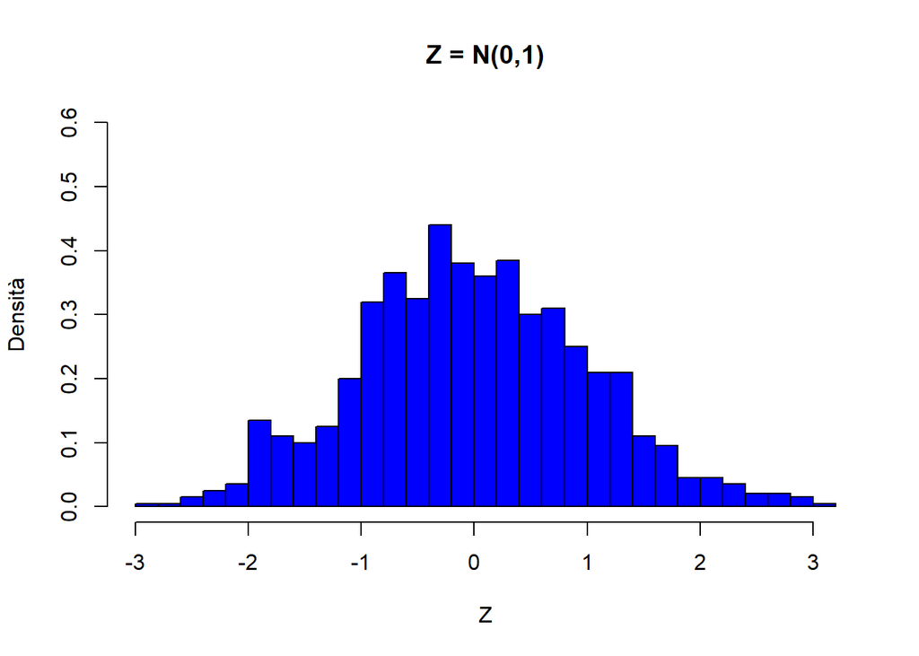

```r
hist(Z,
breaks = 30,
freq=FALSE,
main="Z = N(0,1)",
col ="blue",
ylab="Densità",
ylim =c(0,0.6))
```

Per generare 10 realizzazioni da una distribuzione di Gauss tale che $𝑋 \sim 𝑁(4, 16)$ si può applicare la trasformazione $(𝑍⋅\sigma +\mu)$ dove 𝑍 rappresentano i generati dalla Normale standard oppure utilizzare la funzione specificando media e deviazione standard

```r
rnorm(10,mean = 4, sd = 4 )
```

```
##  [1] -3.321001  1.193820 12.282747  5.945237 -3.245020 -6.574799  1.855293
##  [8]  9.809065  1.054175 -3.303407
```

### Generazione dalla variabile casuale Esponenziale

Nel seguente chuck si crea una griglia di 101 valori e si calcola la densità della v.c. esponenziale con $\lambda = 1$ nei punti generati

```r
x<-seq(0,5,length=101)
head(x)
```

```
## [1] 0.00 0.05 0.10 0.15 0.20 0.25
```

```r
h<-dexp(x,rate = 1)
head(h)
```

```
## [1] 1.0000000 0.9512294 0.9048374 0.8607080 0.8187308 0.7788008
```

La media della v.c. è 1 e la varianza è 1.

Nel seguente grafico si rappresenta la funzione di densità

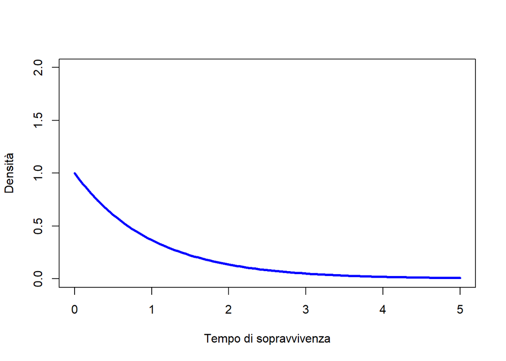

```r
plot(x,h,
type="l", col = "blue",
lwd = 3, ylim = c(0,2),
xlab = "Tempo di sopravvivenza", ylab = "Densità")
```

Si generano 1000 volte delle realizzazioni da v.c. esponenziali indipendenti con $\lambda=1$. Nel seguente si fissa una numerosità campionaria, si generano 3 realizzazioni dalla v.c. esponenziale di riferimento, si calcola la media aritmetica delle tre realizzazioni e si salvano nell’oggetto $m$

```r
n<-3
m<-rep(0,1000)
for(i in 1:1000){
m[i]<-mean(rexp(n, rate=1))
}
head(m)
```

```
## [1] 0.4708260 0.3383811 0.3472054 0.7999226 0.5198195 0.4173393
```

Si sovrappone l’istogramma dei valori generati alla curva disegnata in precedenza

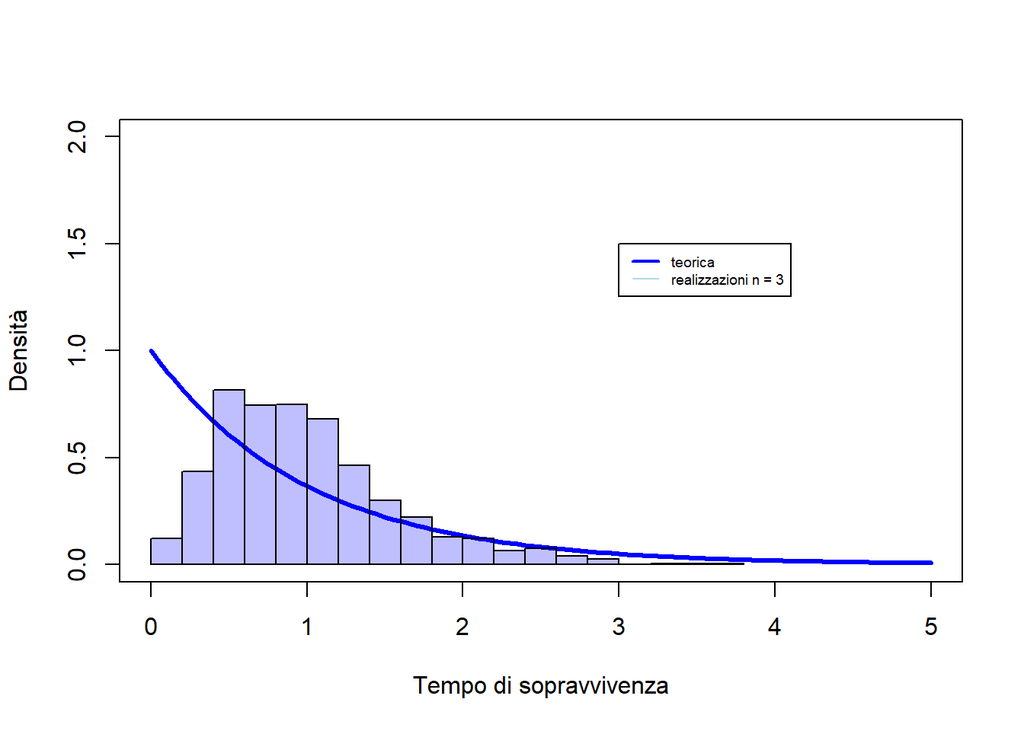

```r
plot(x,h,
type="l", col = "blue",
lwd = 3, ylim = c(0,2),
xlab = "Tempo di sopravvivenza", ylab = "Densità")
hist(m, prob= T, add=T, col = rgb(0,0,1,1/4), breaks = 25)
legend(3,1.5, c("teorica", "realizzazioni n = 3"),
col = c("blue", "lightblue"),
lty = c(1,1),
lwd = c(2,1),
cex = 0.6)
```

Per il teorema del limite centrale sappiamo che c’è la covergenza alla distribuzione Normale.

### Generazione di pseudo-derminazioni dalla v.c. Beta

La distribuzione $Beta(\alpha, \beta)$ è definita per valori di $0 < 𝑥 < 1$ e per $\beta, \beta > 0$. Si generano 1000 osservazioni dalla distribuzione beta standard con $\alpha= 1$ and $\beta = 1$. Si tratta della distribuzione uniforme in $U(0, 1)$

```r
n<-1000
set.seed(27732)
alpha <- 1
beta<- 1
B <- rbeta(n,alpha,beta)
summary(B)
```

```
##      Min.   1st Qu.    Median      Mean   3rd Qu.      Max.
## 0.0006886 0.2503327 0.5137247 0.5056517 0.7635183 0.9983702
```

Si disegna l’istogramma

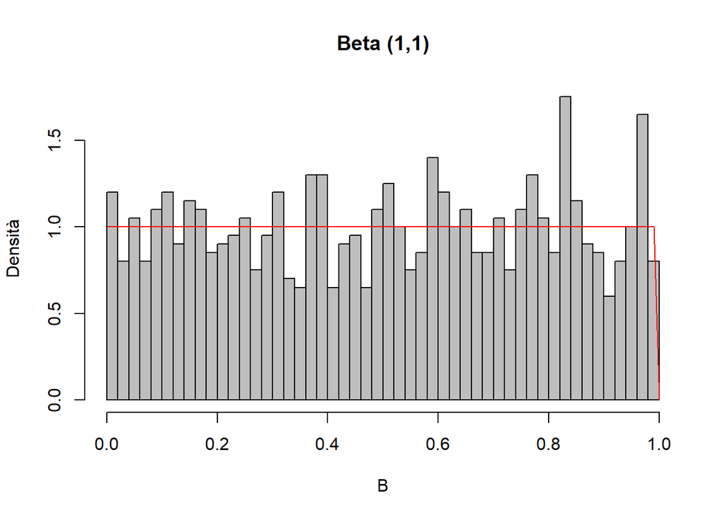

```r
hist(B,
breaks = 50,
freq=FALSE,
main="Beta (1,1)",
col ="grey",
ylab="Densità"
)
curve(dbeta(x,1,1),
col = "red",
add = TRUE )
```

Si nota dalle statistiche descrittive che i numeri possono essere assunte come determinazioni pseudo-casuali. - Si ottengono ancora 1000 realizzazioni ponendo $\alpha = 0.5$ e $\beta = 0.7$ e si sovrappone la curva teorica generata attraverso la funzione dbeta.

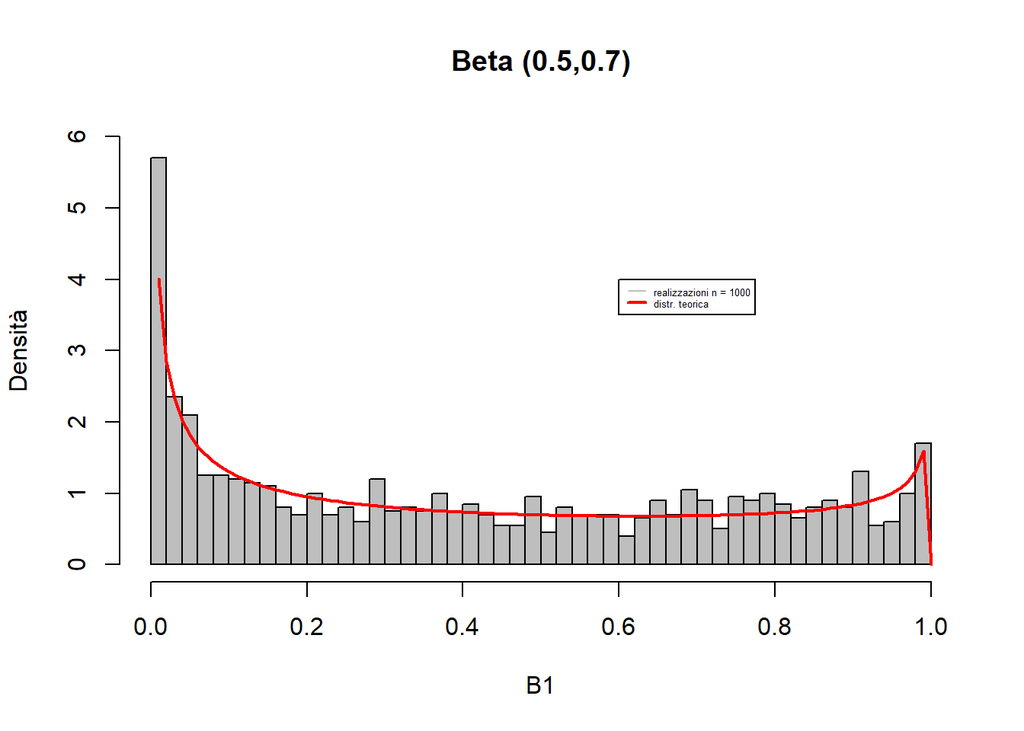

```r
alpha <- 0.5
beta <- 0.7
B1 <- rbeta(n,alpha,beta)
#
hist(B1,
breaks = 50,
freq=FALSE,
main="Beta (0.5,0.7)",
col ="grey",
ylab="Densità",
ylim=c(0,6)
)
#
curve(dbeta(x,alpha,beta),
col = "red",
add = TRUE, lwd=2 )
legend(0.6,4, c("realizzazioni n = 1000",
"distr. teorica"),
col = c("grey", "red"),
lty = c(1,1),
lwd = c(1,2),
cex = 0.4)
```

### Generazione di pseudo-derminazioni dalla v.c. Binomiale

```r
y= seq(0, 12, 1); y
```

```
##  [1]  0  1  2  3  4  5  6  7  8  9 10 11 12
```

```r
dy <- dbinom(y,12,0.2); dy
```

```
##  [1] 6.871948e-02 2.061584e-01 2.834678e-01 2.362232e-01 1.328756e-01
##  [6] 5.315022e-02 1.550215e-02 3.321889e-03 5.190451e-04 5.767168e-05
## [11] 4.325376e-06 1.966080e-07 4.096000e-09
```

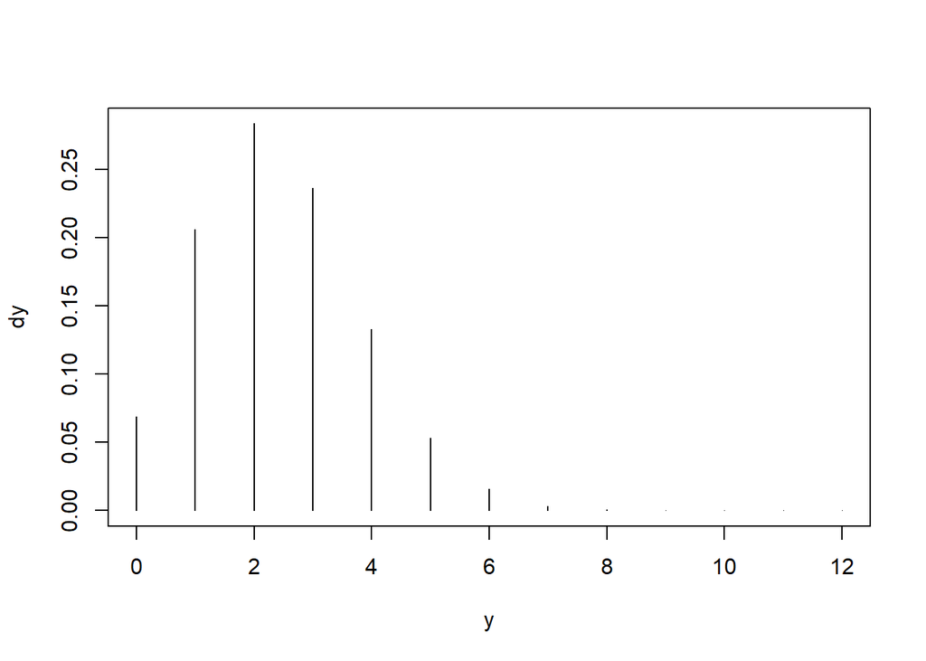

```r
plot(y, dy, type="h")
```

Per generare dei numeri dalla distribuzione Binomiale si utilizza rbinom. Con il seguente codice si genera una realizzazione del risultato di un esperimento un cui la probabilità dell’evento successo è 0.2 e si ripete l’esperimento per 8 volte

```r
set.seed(123)
rbinom(1, 8, 0.20)
```

```
## [1] 1
```

ovvero su 8 prove si riscontra solo un successo.

Il seguente codice permette di simulare 8 realizzazioni di un esperimento in cui la probabilità di successo è sempre 0.2

```r
rbinom(8, 1, 0.20)
```

```
## [1] 0 0 1 1 0 0 1 0
```

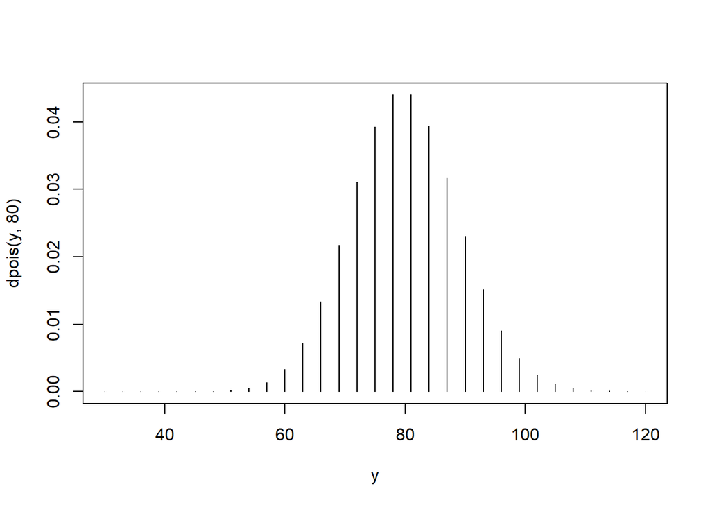

```r
y = seq(30, 120, 3)
plot(y, dpois(y, 80), type='h')
```

Si rappresenta la densità di Poisson fissando la media a 80 Per generare 100 realizzazioni dalla distribuzione di Poisson con parametro $\lambda = 22$ si utilizza:

```r
set.seed(163)
y <- rpois(100, 22); y
```

```
##   [1] 19 21 14 20 19 26 13 23 19 25 19 25 30 17 22 22 30 25 22 17 17 25 17 29 16
##  [26] 24 18 19 26 19 25 27 18 25 22 25 22 26 21 21 21 16 17 28 13 22 18 25 24 23
##  [51] 31 24 23 22 25 17 20 17 19 15 16 27 25 27 23 15 17 23 27 24 13 15 20 20 17
##  [76] 20 29 21 25 23 24 22 22 11 25 19 22 18 19 25 26 27 27 25 22 20 14 22 20 19
```

```r
mean(y)
```

```
## [1] 21.46
```

```r
var(y)
```

```
## [1] 18.57414
```

# Modello lineare generalizzato per i conteggi basato sulla distribuzione Binomiale Negativa

Si considerino i seguenti dati riguardanti dei grachi particolari ( per sapere cosa sono si rimanda al seguente video https://www.youtube.com/watch?v=6gydJh6rP50). Si tratta di 173 femmine di granchi. Durante la stagione della deposizione delle uova, una femmina migra verso la riva per riprodursi. Con un maschio attaccato alla sua spina dorsale posteriore, si scava nella sabbia e depone grappoli di uova. Le uova sono fecondate esternamente. Durante la deposizione delle uova, altri granchi maschi, chiamati satelliti, possono raggrupparsi intorno alla coppia e fecondare anche le uova. Per ogni granchio femmina si intende modellizzare il numero di satelliti (sat). Le variabili esplicative sono il colore del granchio femmina (color 1 = medio chiaro; 2 = medio; 3 = medio scuro; 4 = scuro), la condizione della spina dorsale (spine 1 = entrambe buone; 2 = una consumata o rotta; 3 = entrambe consumate o rotte), la larghezza del carapace (width in cm) e il peso (weightin kg). Il colore è un surrogato dell’età del granchio, poiché i granchi più vecchi tendono ad avere un colore più scuro.

Si caricano i dati dal seguente sito

```r
Crabs <- read.table("http://stat4ds.rwth-aachen.de/data/Crabs.dat", header=TRUE)
head(Crabs)
```

```
##   crab sat y weight width color spine
## 1    1   8 1   3.05  28.3     2     3
## 2    2   0 0   1.55  22.5     3     3
## 3    3   9 1   2.30  26.0     1     1
## 4    4   0 0   2.10  24.8     3     3
## 5    5   4 1   2.60  26.0     3     3
## 6    6   0 0   2.10  23.8     2     3
```

```r
require(skimr)
```

```r
skimr::skim_without_charts(Crabs)
```

Data summary

| Name | Crabs |
| --- | --- |
| Number of rows | 173 |
| Number of columns | 7 |
| _______________________ |  |
| Column type frequency: |  |
| numeric | 7 |
| ________________________ |  |
| Group variables | None |

**Variable type: numeric**

| skim_variable | n_missing | complete_rate | mean | sd | p0 | p25 | p50 | p75 | p100 |
| --- | --- | --- | --- | --- | --- | --- | --- | --- | --- |
| crab | 0 | 1 | 87.00 | 50.08 | 1.0 | 44.0 | 87.00 | 130.00 | 173.0 |
| sat | 0 | 1 | 2.92 | 3.15 | 0.0 | 0.0 | 2.00 | 5.00 | 15.0 |
| y | 0 | 1 | 0.64 | 0.48 | 0.0 | 0.0 | 1.00 | 1.00 | 1.0 |
| weight | 0 | 1 | 2.44 | 0.58 | 1.2 | 2.0 | 2.35 | 2.85 | 5.2 |
| width | 0 | 1 | 26.30 | 2.11 | 21.0 | 24.9 | 26.10 | 27.70 | 33.5 |
| color | 0 | 1 | 2.44 | 0.80 | 1.0 | 2.0 | 2.00 | 3.00 | 4.0 |
| spine | 0 | 1 | 2.49 | 0.83 | 1.0 | 2.0 | 3.00 | 3.00 | 3.0 |

```r
table(Crabs$sat)
```

```
##
##  0  1  2  3  4  5  6  7  8  9 10 11 12 14 15
## 62 16  9 19 19 15 13  4  6  3  3  1  1  1  1
```

Si nota che ben 62 femmine non hanno satelliti e che la media è 2.92 mentre la varianza è 9.9 per cui molto superiore alla media. Poche (4) hanno un numero di satelliti superiore a 10.

La distribuzione empirica è la seguente

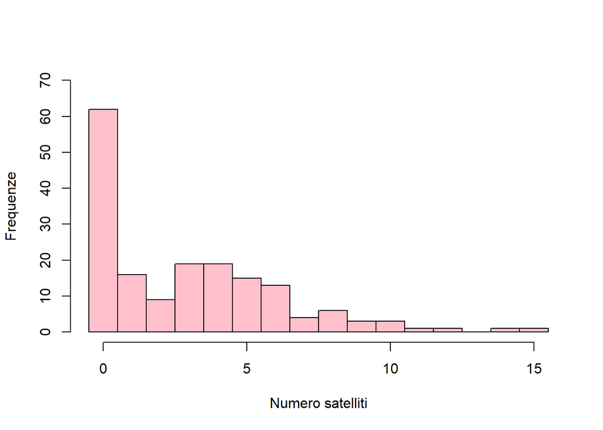

```r
hist(Crabs$sat, breaks=c(0:16)-0.5,
ylim = c(0,70),
col = "pink", ylab = "Frequenze",
xlab = "Numero satelliti",
main = " ")
```

Utilizzando la distribuzione BN si stima il seguente modello lineare generalizzato considerando come variabili esplicative il peso e il colore.

```r
library(MASS)
stima <- glm.nb(sat ~ weight + factor(color), link=log, data=Crabs)
summary(stima)
```

```
##
## Call:
## glm.nb(formula = sat ~ weight + factor(color), data = Crabs,
##     link = log, init.theta = 0.9596400657)
##
## Coefficients:
##                Estimate Std. Error z value Pr(>|z|)
## (Intercept)     -0.4263     0.5382  -0.792    0.428
## weight           0.7121     0.1615   4.410 1.04e-05 ***
## factor(color)2  -0.2527     0.3486  -0.725    0.468
## factor(color)3  -0.5218     0.3799  -1.373    0.170
## factor(color)4  -0.4804     0.4282  -1.122    0.262
## ---
## Signif. codes:  0 '***' 0.001 '**' 0.01 '*' 0.05 '.' 0.1 ' ' 1
##
## (Dispersion parameter for Negative Binomial(0.9596) family taken to be 1)
##
##     Null deviance: 220.01  on 172  degrees of freedom
## Residual deviance: 196.56  on 168  degrees of freedom
## AIC: 757.94
##
## Number of Fisher Scoring iterations: 1
##
##
##               Theta:  0.960
##           Std. Err.:  0.175
##
##  2 x log-likelihood:  -745.935
```

e si nota che il colore non risulta significativo ma solo peso è rilevante. La stima parametro di dispersione (forma della distribuzione) è 0.9596 e pertanto l’overdispersion è

```r
1/0.9596
```

```
## [1] 1.042101
```

# Analisi della serie storica dei conteggi riferiti a COVID- 19

## 1. Modello autoregressivo di Poisson non omogeneo

Nel presente esempio (tratto da Bartolucci e Pennoni, 2020) si stima un modello di Poisson non omogeneo nel tempo considerando la serie dei conteggi dei casi di pazienti affetti da COVID-19.

I dati sono quelli forniti giornalmente a livello ufficiale dal Dipartimento della Protezione Civile sull’andamento del COVID-19 in Italia.

La serie inizia con i conteggi del giorno 24 Febbraio 2020 (primo giorno di rilevazione) e viene incrementata ogni giorno.

Nel seguente esempio si considerano i dati riferiti al periodo temporale più recente dal 1 Agosto fino al 20 Ottobre 2022.

I dati sono di libero accesso nella piattaforma GITHUB e con la seguente sintassi si importano nel workspace direttamente dal repository e si selezionano alcune delle categorie disponibili. Si noti che con il seguente chunck prima si importa il dataframe con i conteggi di tutte le date disponibili fino al giorno corrente e poi con la funzione subset si seleziona il perido di interesse

```r
repository       <- "https://raw.githubusercontent.com/pcm-dpc/COVID-19/master/"
overall.dataset  <- "dati-andamento-nazionale/dpc-covid19-ita-andamento-nazionale.csv"
overall.filename <-paste(repository,overall.dataset,sep="")
Italy<-read.csv(overall.filename)
names(Italy)
```

```
##  [1] "data"
##  [2] "stato"
##  [3] "ricoverati_con_sintomi"
##  [4] "terapia_intensiva"
##  [5] "totale_ospedalizzati"
##  [6] "isolamento_domiciliare"
##  [7] "totale_positivi"
##  [8] "variazione_totale_positivi"
##  [9] "nuovi_positivi"
## [10] "dimessi_guariti"
## [11] "deceduti"
## [12] "casi_da_sospetto_diagnostico"
## [13] "casi_da_screening"
## [14] "totale_casi"
## [15] "tamponi"
## [16] "casi_testati"
## [17] "note"
## [18] "ingressi_terapia_intensiva"
## [19] "note_test"
## [20] "note_casi"
## [21] "totale_positivi_test_molecolare"
## [22] "totale_positivi_test_antigenico_rapido"
## [23] "tamponi_test_molecolare"
## [24] "tamponi_test_antigenico_rapido"
```

```r
library(dplyr)
dataItaly<- Italy %>%
select(data,
dimessi_guariti,
isolamento_domiciliare,
ricoverati_con_sintomi,
terapia_intensiva,deceduti)
mydate <- as.Date(as.POSIXct(dataItaly$data, format="%Y-%m-%dT %H:%M:%S"))
df<-data.frame(mydate,dataItaly$isolamento_domiciliare)
colnames(df)<-c("date", "Isolati")
df1 <- subset(df, date >= as.Date('2022-08-01') & date <= as.Date('2022-10-20'))
```

Si nota che vi sono 24 campi disponibili per i dati nazionali.

```r
min(df$date)
```

```
## [1] "2020-02-24"
```

```r
max(df$date)
```

```
## [1] "2023-10-18"
```

Il data frame df1 invece considera l’ultimo periodo.

L’utilizzo del modelli di Poisson permette anche di tenere conto in modo adeguato delle irregolarità presenti nei dati, e pertanto i valori interpolati creano una sorta di effetto smoothing o lisciamento ai dati osservati.

```r
require(skimr)
skimr::skim_without_charts(df1$Isolati)
```

Data summary

| Name | df1$Isolati |
| --- | --- |
| Number of rows | 81 |
| Number of columns | 1 |
| _______________________ |  |
| Column type frequency: |  |
| numeric | 1 |
| ________________________ |  |
| Group variables | None |

**Variable type: numeric**

| skim_variable | n_missing | complete_rate | mean | sd | p0 | p25 | p50 | p75 | p100 |
| --- | --- | --- | --- | --- | --- | --- | --- | --- | --- |
| data | 0 | 1 | 640634.8 | 227705.8 | 409247 | 463524 | 536906 | 772106 | 1243828 |

Si rappresenta graficamente la serie osservata

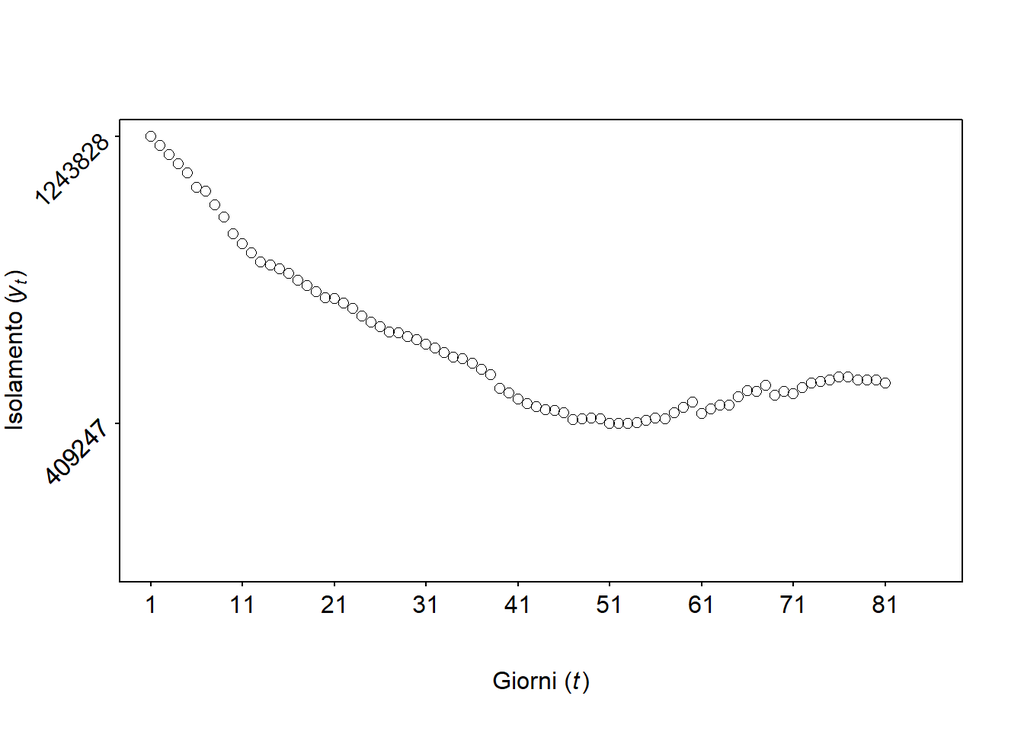

```r
n<-length(df1$Isolati)
ma<-max(df1$Isolati)
mi<-min(df1$Isolati)
ytick<-c(mi,409247,ma)
xtick<-c(1,11, 21, 31, 41, 51, 61, 71, 81)
plot(df1$Isolati,
ylab=expression("Isolamento ("*italic(y[t])*")"),
xlab=expression("Giorni ("*italic(t)*")"),
yaxt="n",
xaxt="n",
xlim =c(1,n+5),ylim = c(0,ma+10),
lwd = 0.5,
lty = 1,col ="black" )
axis(side=2, at=ytick, labels = FALSE,
cex.lab = 0.5, padj = 2,tck=-0.009)
text(par("usr")[1],
ytick,
labels = ytick, srt = 45,
pos = 2, xpd = TRUE, cex.lab = 0.1)
axis(side=1, at=xtick,
labels = FALSE, cex=0.1,tck=-0.009)
text(x=xtick,
par("usr")[3],
labels = xtick,
cex.lab = 0.5,
pos = 1, xpd = TRUE)
```

Il modello di Poisson non omogeneo si stima definendo le covariate riferite al tempo e menzionate in precedenza: il trend lineare, quadratico e log-lineare nel modo seguente

```r
regressors1Italy <- cbind(linearTrend=seq(along=df1$Isolati),
quadTrend = seq(along=df1$Isolati)^2/100,
linlogTrend = log(seq(along=df1$Isolati)))
head(regressors1Italy)
```

```
##      linearTrend quadTrend linlogTrend
## [1,]           1      0.01   0.0000000
## [2,]           2      0.04   0.6931472
## [3,]           3      0.09   1.0986123
## [4,]           4      0.16   1.3862944
## [5,]           5      0.25   1.6094379
## [6,]           6      0.36   1.7917595
```

Per stimare il modello con il metodo della massima versosimiglianza si utilizza la funzione tscount::tsglm della libreria (da installare, tscount proposta da Liboschik et al., 2020) (Analysis of Count Time Series)

Si noti che la prima opzione del chunk seguente serve per rimuovere la notazione scientifica che alcune volte può essere stampata in output.

```r
options(scipen = 100)
require(tscount)
M3Italy <- tsglm(ts=df1$Isolati,
link = "log",
model=list(past_obs=1),
xreg=regressors1Italy,
distr = "poisson")
```

Come già sperimentato per la funzione glm occorre fornire: - i dati osservati come serie univariata dei conteggi, - la funzione link per il modello log-lineare per 𝜆𝑡, - definire l’ordine del ritardi con past_obs, - la matrice delle covariate temporali xreg e la distribuzione di riferimento.

```r
summary(M3Italy)
```

```
##
## Call:
## tsglm(ts = df1$Isolati, model = list(past_obs = 1), xreg = regressors1Italy,
##     link = "log", distr = "poisson")
##
## Coefficients:
##              Estimate  Std.Error  CI(lower)  CI(upper)
## (Intercept)   0.86375   0.034280    0.79656    0.93093
## beta_1        0.93892   0.002431    0.93415    0.94368
## linearTrend   0.00619   0.000122    0.00595    0.00643
## quadTrend    -0.00489   0.000103   -0.00509   -0.00469
## linlogTrend  -0.05969   0.000516   -0.06070   -0.05868
## Standard errors and confidence intervals (level =  95 %) obtained
## by normal approximation.
##
## Link function: log
## Distribution family: poisson
## Number of coefficients: 5
## Log-likelihood: -29574.38
## AIC: 59158.76
## BIC: 59170.73
## QIC: 59158.76
```

Viene fornito in output il valore massimo della funzione di log-verosimiglianza a convergenza, il numero dei parametri stimati con il modello, ed i valori degli indici di selezione BIC (criterio d’informazione Bayesiano), AIC (criterio di Akaike) e una sua versione aggiustata definita QIC (quasi information criterion).

Dalla sintesi dei risultati delle stime del modello notiamo che l’intercetta del modello ha un valore positivo e corrisponde al valore del logaritmo di lambda quando tutte le covariate hanno valore 0.

Le stime dei coefficienti di regressione sono fornite insieme all’intervallo di confidenza calcolato al livello del 95% utilizzando il metodo asintotico (basato sull’approssimazione dello stimatore alla distribuzione Normale).

Si noti che tutti i coefficienti sono positivi tranne i due coefficienti riferito al trend quadratico e al trend log-lineare nel tempo.

Si noti che è di particolare interesse confrontare i valori osservati con i valori interpolati. E’ inoltre di interesse fare delle previsioni: calcolare i conteggi attesi in base al modello stimato per gli isolati di oggi (20 ottobre 2022) e per quelli dei prossimi 4/5 giorni.

Come per la funzione glm i valori previsti si ottengono con la funzione predict.

Si noti che la funzione tsglm::predict implementa il method=“bootstrap” ovvero la distribuzione dei valori previsti è approssimata con il bootstrap parametrico basato di default su B = 1000 traiettorie simulate dal modello stimato. Si noti che in questo modo si associa alla stima puntuale della previsione un intervallo definito intervallo predittivo calcolato con una confidenza di 0.95.

```r
go <- 5
TT <- length(df1$date)
P3Italy <-predict(M3Italy,
newxreg = data.frame(linearTrend = ((TT+1):(TT+go)),
quadTrend = ((TT+1):(TT+go))^2/100,
linlogTrend = log((TT+1):(TT+go))),
n.ahead=go,
method="bootstrap" )
```

La seguente tabella riporta i valori previsti degli isolati, insieme ai limiti dell’intervallo predittivo al 95%, per oggi e per i prossimi 4 giorni

```r
pred<-data.frame(cbind(P3Italy$pred,P3Italy$interval))
colnames(pred)<-c("previsti", "PIinf", "PIsup")
pred
```

```
##   previsti  PIinf  PIsup
## 1 514103.7 512780 515516
## 2 500611.5 498653 502346
## 3 486952.6 484739 488954
## 4 473149.1 470835 475373
## 5 459224.2 456703 461674
```

Si nota che il numero degli isolati atteso per domani è di 514103 ed il trend è quello che iil numero decresca nei giorni successivi.

Si nota che le ampiezze degli intervalli sono modeste e che queste crescono al crescere del giorno previsto. Ciò denota, come ci si aspetta, un aumento dell’incertezza delle previsioni via via che ci si allontana dall’ultima data di osservazione.

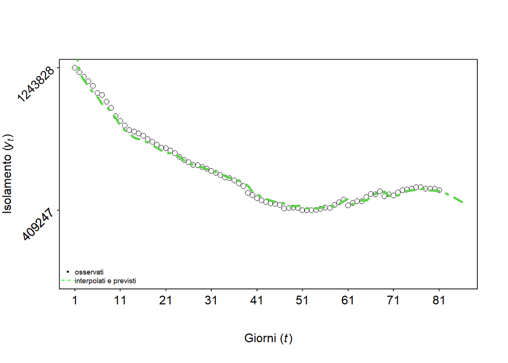

```r
ytick<-c(mi,409247,ma)
xtick<-c(1,11, 21, 31, 41, 51, 61, 71, 81)
plot(df1$Isolati,
ylab=expression("Isolamento ("*italic(y[t])*")"),
xlab=expression("Giorni ("*italic(t)*")"),
yaxt="n",
xaxt="n",
xlim =c(1,n+5),
ylim = c(0,ma),
lwd = 0.5,
lty = 1,col ="black" )
abline(v=240, col = "gray")
axis(side=2, at=ytick, labels = FALSE,
cex.lab = 0.5, padj = 2,tck=-0.009)
text(par("usr")[1],
ytick,
labels = ytick, srt = 45,
pos = 2, xpd = TRUE, cex.lab = 0.1)
axis(side=1, at=xtick,
labels = FALSE, cex=0.1,tck=-0.009)
text(x=xtick,
par("usr")[3],
labels = xtick,
cex.lab = 0.5,
pos = 1, xpd = TRUE)
lines(c(M3Italy$fitted.values,
pred$previsti),
lwd=3, col = 3, lty = 4)
legend("bottomleft",
       pch = c(20,NA,NA,NA,NA),
lty = c(NA,2),
legend = c("osservati", "interpolati e previsti"),
col = c("black", "green"),
bty = "n",
x.intersp = 0.1,
cex= 0.6, pt.cex = .5,
xpd = TRUE,
text.width = 0.0001)
```

## Modello autoregressivo con distribuzione Binomiale Negativa

Il modello basato sulla distribuzione Binomiale Negativa include il parametro di overdispersion in modo che la il valore atteso dei conteggi è 𝜆̂𝑡 mentre la varianza è diversa dal valore atteso e risulta $\hat{\lambda}(1+\hat{\lambda}.\hat{\sigma^2})$

```r
options(scipen = 100)
require(tscount)
M4Italy <- tsglm(ts=df1$Isolati,
link = "log",
model=list(past_obs=1),
xreg=regressors1Italy,
distr = "nbinom")
```

ovvero specificando la distribuzione Binomiale Negativa con distr = “nbinom”. In questo caso il modello presenta un parametro aggiuntivo riferito a $\sigma^2$

```r
summary(M4Italy)
```

```
##
## Call:
## tsglm(ts = df1$Isolati, model = list(past_obs = 1), xreg = regressors1Italy,
##     link = "log", distr = "nbinom")
##
## Coefficients:
##              Estimate  Std.Error  CI(lower)  CI(upper)
## (Intercept)   0.86375    0.87043  -0.842271   2.569761
## beta_1        0.93892    0.06192   0.817555   1.060276
## linearTrend   0.00619    0.00354  -0.000759   0.013134
## quadTrend    -0.00489    0.00295  -0.010667   0.000887
## linlogTrend  -0.05969    0.01779  -0.094550  -0.024833
## sigmasq       0.00105         NA         NA         NA
## Standard errors and confidence intervals (level =  95 %) obtained
## by normal approximation.
##
## Link function: log
## Distribution family: nbinom (with overdispersion coefficient 'sigmasq')
## Number of coefficients: 6
## Log-likelihood: -914.3805
## AIC: 1840.761
## BIC: 1855.128
## QIC: 67318.39
```

Per calcolare l’errore standard occorre applicare il bootstrap che verrà introdotto nei giorni seguenti.

```r
go <- 5
TT <- length(df1$date)
P4Italy <-predict(M4Italy,
newxreg = data.frame(linearTrend = ((TT+1):(TT+go)),
quadTrend = ((TT+1):(TT+go))^2/100,
linlogTrend = log((TT+1):(TT+go))),
n.ahead=go,
method="bootstrap" )
pred<-cbind(P4Italy$pred,P4Italy$interval)
colnames(pred)<-c("previsti", "PIinf", "PIsup")
pred
```

```
##      previsti  PIinf  PIsup
## [1,] 514103.7 481137 547798
## [2,] 500611.5 458864 547757
## [3,] 486952.6 440011 540023
## [4,] 473149.1 421656 530036
## [5,] 459224.2 405014 519757
```

E’ interessante notare che il valore puntuale del conteggio previsto è simile a quello ottenuto con il modello di Poisson tuttavia in base all’overdispersion l’itervallo predittivo calcolato con una fiducia di 0.95 ha maggiore ampiezza.

I conteggi osservati dei pazienti isolati per tutto il periodo considerato insieme ai valori interpolati con il modello stimato e i valori previsti possono essere rappresentati graficamente

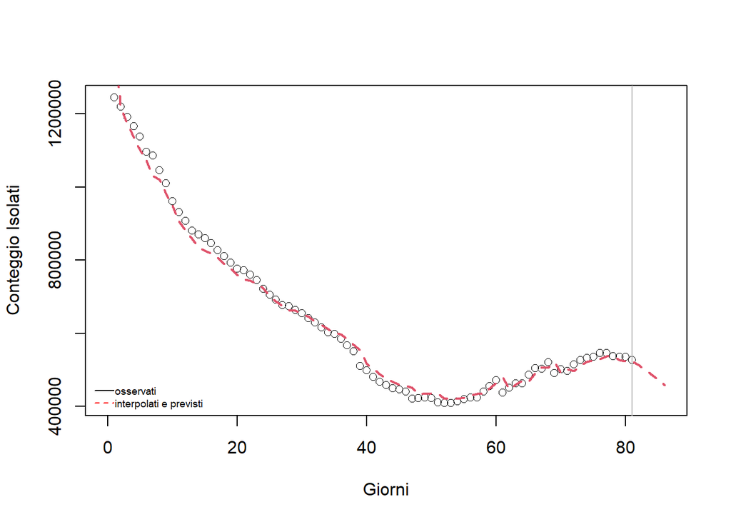

```r
plot(df1$Isolati, lwd = 0.5,
lty = 1,col ="black",
xlab = "Giorni",
ylab= "Conteggio Isolati",
ylim = c(mi,ma+2), xlim = c(0,n+5))
abline(v=81, col = "gray")
lines(c(M4Italy$fitted.values,P4Italy$pred),
lwd=2, col = 2, lty = 2)
legend("bottomleft",
lty = c(1,2),
legend = c("osservati", "interpolati e previsti"),
col = c("black", "red"),
bty = "n",
x.intersp = 0.1,
cex= 0.6, pt.cex = .5,
xpd = TRUE,
text.width = 0.0001)
```

# Valutazione della prevalenza nel tempo

Considerando la popolazione complessiva è possibile stimare in base al modello la prevalenza che misura la proporzione dell’evento (Isolamento nel presente caso) in una popolazione in un dato momento.

Per l’Italia la numerorità della popolazione totale è reperibile dal sito dell’Istituto Nazionale di Statistica che riporta che popolazione residente al 1 Gennario 2020 è di 60317000 unità https://www.istat.it/it/archivio/238447

Utilizzando quest’informazione è possibile calcolare la prevalenza dividendo i valori per questo numero (e moltiplicando per mille)

```r
prev<-c(M4Italy$fitted.values,P4Italy$pred)/60317000
prev<-prev*1000
```

E verificare in base al modello stimato come questa si è modificata nel tempo ad esempio con il seguente grafico

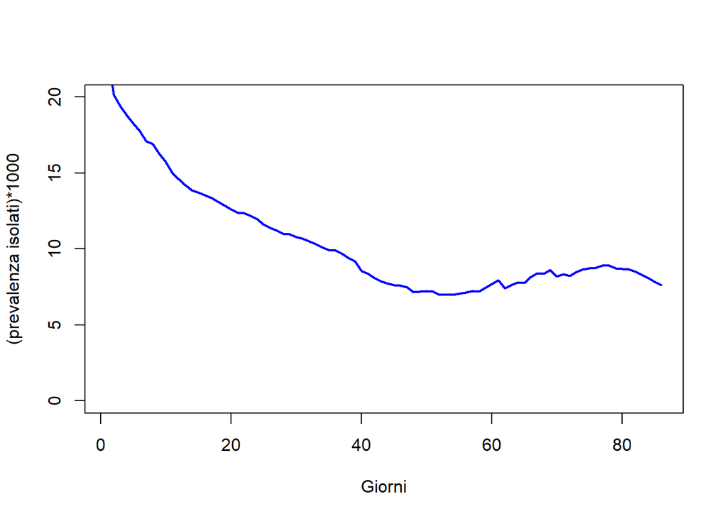

```r
plot(prev, type = "l",
xlab = "Giorni",
ylim = c(0,20),
lwd=2,
col = "blue", ylab = "(prevalenza isolati)*1000")
```

che permette di evidenziare la prevalenza di casi ogni 1000 abitanti. In questo modo è possibile anche fare confronti tra diversi paesi.

# Generazione di realizzazioni da variabili casuali

## Esercizio 14

Si generino 1000 pseudo-realizzazioni dalla variabile casuale Esponenziale con parametro $\lambda$ = 0.4. 1. Si descrivano le osservazioni ottenute. 2. Si disegni la distribuzione empirica e si sovrapponga la linea della distribuzione teorica. 3. Si generino altre 1000 pseudo-determinazioni con $\lambda$ = 0.25 e si confrontino in un’unica finestra grafica i due grafici ottenuti come specificato nel punto 2. 4. Si disegnino nello stesso grafico le due funzioni di ripartizione e si inserisca la legenda. Si commenti.

14.1

Si utilizza la funzione rexp() per generare le osservazioni richieste. La funzione richiede solo il numero di punti da generare e il valore di $\lambda$ (rate).

```r
x <- rexp(1000, rate = 0.4)
```

Per valutare le osservazioni generate calcoliamo i valori di media e varianza campionarie, confrontandole poi con i valori teorici noti per le variabile casuale esponenziale $E[X]= 1/\lambda = 2.5 ; V[X]= 1/\lambda^2 = 6.25$

```r
summary(x)
```

```
##      Min.   1st Qu.    Median      Mean   3rd Qu.      Max.
##  0.005473  0.766107  1.801336  2.607217  3.639141 25.178417
```

```r
var(x)
```

```
## [1] 7.018023
```

14.2 Rappresentiamo la distribuzione empirica sotto forma di istogramma. Sovrapponiamo poi al grafico la curva della distribuzione teorica.

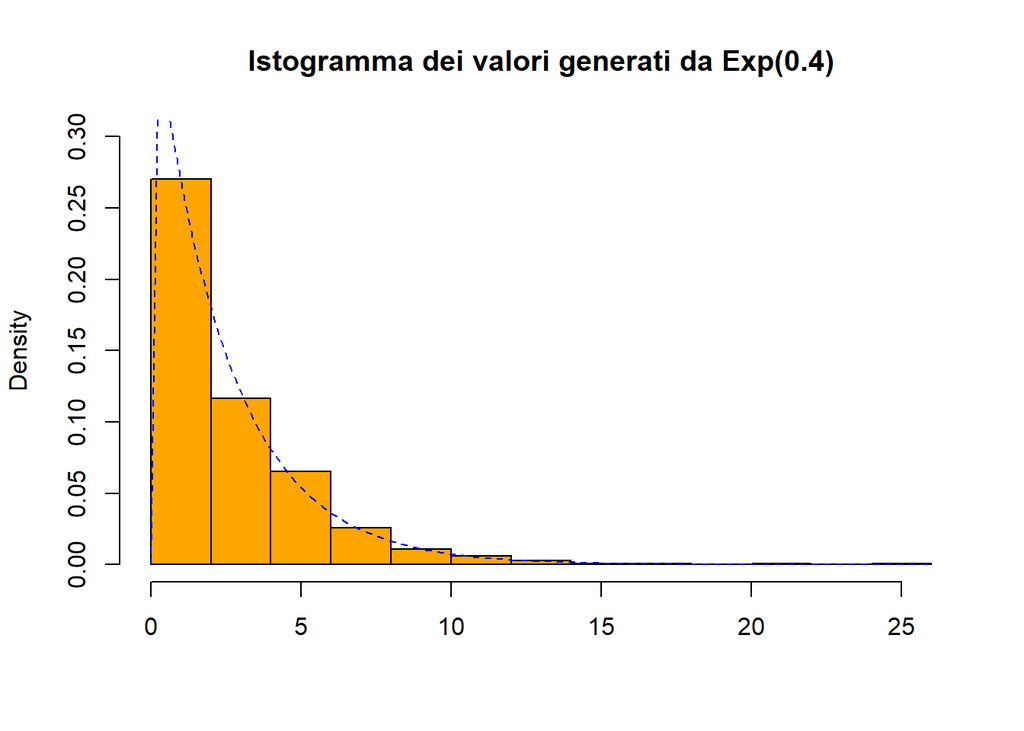

```r
hist(x, freq = FALSE,
xlab = "", main = "Istogramma dei valori generati da Exp(0.4)",
ylim = c(0, 0.3),
col = "orange")
curve(dexp(x, rate = 0.4),
lty = 2, col = "blue", add = TRUE)
```

L’istogramma della distribuzione empirica aderisce alla curva della funzione di densità teorica.

14.3 Aggiungiamo ora al grafico precedente la rappresentazione delle nuove osservazioni generate da una variabile Esponenziale con $\lambda$ = 0.25.

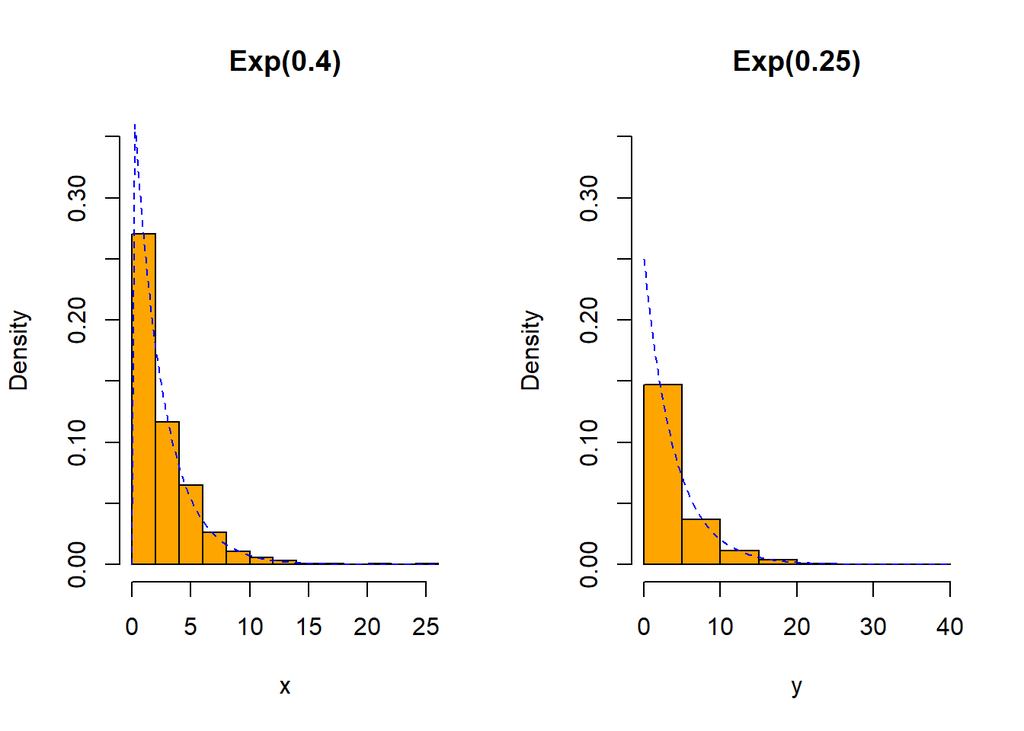

```r
y <- rexp(1000, rate = 0.25)
par(mfrow = c(1, 2))
hist(x, freq = FALSE,
col = "orange",
ylim = c(0, 0.35),
main = "Exp(0.4)")
curve(dexp(x, rate = 0.4),
col = "blue", lty = 2,
add = TRUE)

hist(y, freq = FALSE,
col = "orange",
ylim = c(0, 0.35),
main = "Exp(0.25)")
curve(dexp(x, rate = 0.25),
col = "blue", lty = 2,
add = TRUE)
```

Fissando il range dell’asse Y in modo da poter confrontare le due distribuzioni più facilmente, osserviamo che quella con parametro $\lambda$ = 0.25 ha una variabilità molto più elevata (la varianza è del resto inversamente proporzianale al valore di 𝑙𝑎𝑚𝑏𝑑𝑎). il campo di variazione della prima varia infatti approssimativamente tra 0 e 15, quello della seconda tra 0 e 30. Entrambe gli istogrammi aderiscono alle rispettive curve teoriche.

14.4 Infine rappresentiamo in un unico grafico le due funzioni di ripartizioni empiriche.

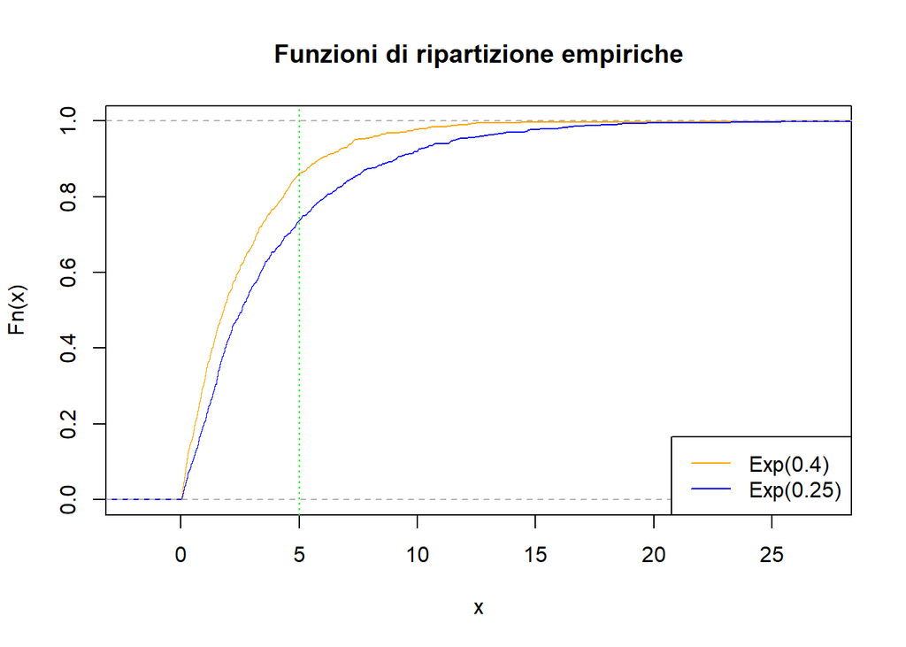

```r
plot(ecdf(x),
col = "orange",
do.points = FALSE,
main = "Funzioni di ripartizione empiriche")
plot(ecdf(y),
col = "blue",
do.points = FALSE, add = TRUE)
legend("bottomright",
c("Exp(0.4)", "Exp(0.25)"),
col = c("orange", "blue"),
lty = c(1, 1))
abline(v = 5, col = "green", lty = "dotted")
```

## Esercizio 15

1. Si ottengano 1000 pseudo-determinazioni dalla variable casuale di Gauss con media 175.6 e deviazione standard 7.1 fissando il seme al valore 1734. Si descrivano i dati ottenuti e si commenti.
2. Si disegni l’istogramma della distribuzione e si aggiunga al grafico la funzione di densità teorica corrispondente ai valori dei parametri.
3. Si disegni la funzione di ripartizione empirica.

## Esercizio 16

1. Si rappresenti graficamente la densità della variabile casuale Gamma(𝛼, 𝛽) considerando i seguenti valori dei parametri (𝛼 = 4, 𝛽 = 0.7) e (𝛼 = 2, 𝛽 = 1). Si modifichi il titolo del grafico, l’etichetta dell’asse y e si inserisca la legenda.
2. Si ottengano 1000 realizzazioni da questa variabile casuale con i seguenti valori dei parametri: 𝛼 = 4 e 𝛽 = 0.7. Si riportino delle statistiche descrittive e si commentino.
3. Si disegni l’istogramma dei valori generati e si descriva una tipologia di evento osservato in medicina o biologia la cui distribuzione di riferimento potrebbe essere una Gamma.

## Esercizio 16.1

Si disegni in un unica finestra grafica la densità della distribuzione Gamma fissando la il parametro di forma al valore 3 e facendo variare il parametro di scala ai seguenti valori 0.5, 1, 2, 3, 4, e 5. Si descriva la figura evidenziando l’effetto dell’incremento del valore del parametro di scala.

## Esercizio 16.2

Si consideri la distribuzione Beta e si disegnino in un unica finestra grafica le forme della densità quando 𝛼 = 𝛽 = 0.5, 1.0, 100. Si disegni anche la distribuzione inventando alcuni valori per i parametri tali che risulti 𝛼 > 𝛽. Si descrivano le figure.

## Esercizio 17

1. Si ottengano 1000 pseudo-determinazioni dalla variable casuale Binomiale. Si scelgano i valori dei parametri considerando 31 successi in 41 prove. Si producano le statistiche descrittive dei dati e si commentino i risultati.
2. Si disegni la funzione di ripartizione empirica.

## Esercizio 17.1

Un quiz è costituito da 10 domande a risposta multipla con 5 categorie di risposta ciascuna. Si supponga poi che uno studente sia completamente impreparato e tiri ad indovinare la risposta di ciascuna domanda. Sia 𝑌 il numero di risposte corrette. 1. Si determini la probabilità che lo studente riesca ad indovinare la risposta corretta per tutte le domande, ricevendo un punteggio pari a 10, e la probabilità che viceversa sbagli tutti le risposte, ricevendo così un punteggio pari a zero. 2. Si determini la media e la deviazione standard di 𝑌 .

## Esercizio 17.2

Si consideri la variabile casuale di Poisson. Si descriva la distribuzione elencando alcune tipologie di eventi la cui variabile casuale di riferimento potrebbe essere una Poisson. 1. Si generino 1000 pseudo-determinazioni dalla variabile casuale considerando i seguenti valori del parametro: 𝜆 ∈ 5, 10, 20, 30. Si descrivano i valori ottenuti. 2. Si disegnino le funzioni di ripartizione empiriche dei valori generati in un’unica finestra grafica inserendo la legenda e commentando la figura ottenuta. 3. Si calcoli probabilità 𝑃 (𝑋 = 20|𝜆) per ognuna delle 4 distribuzioni e la si confronti con il valore empirico dei valori ottenuti al punto 1. Si commenti il risultato.

## Esercizio 18

Si leggano in R i seguenti dati http://stat4ds.rwth-aachen.de/data/Afterlife.dat che riguardano un’indagine (General Social Survey) condotta nel 2018 e riportano le risposte alle seguenti domande: credenza nel dopo vita (1 = sì, 2 = no), religione (1 = protestante, 2 = cattolica, 3 = ebraica). Si determini la tabella di contingenza, e si illustrino le distribuzioni congiunta campionaria, marginale e condizionata del post vita in base alla religione dichiarata.

# Modelli di Poisson e Binomiale Negativa per dati di coteggio

## Esercizio 19

Si considerino i dati riferiti ai conteggi dei pazienti affetti da COVID-19 rilasciati dalla Protezione Civile Italiana. 1. Si selezioni la serie dei conteggi dei pazienti in terapia intensiva (osservata dal primo all’ultimo giorno disponibile). Si rappresentino graficamente le osservazioni e si commenti il grafico. 2. Si stimi un modello di Poisson non omogeneo dove il logaritmo naturale del parametro 𝜆𝑡 è in funzione di un trend temporale lineare, quadratico e log-lineare e comprende una componente autoregressiva del primo ordine. Si riportino e si descrivano i valori dei coefficienti stimati. 3. Si forniscano le stime puntuali riferite alle previsioni dei conteggi dei pazienti in terapia intensiva ottenute in base al modello per i prossimi 5 giorni. Utilizzando il metodo bootstrap si fornisca un’intervallo predittivo per ciascun valore dterminato al punto precedente. Si commentino i risultati. 4. Si disegni il grafico dei valori osservati, interpolati e previsti inserendo la legenda.

## Esercizio 20

Si svolgano i punti dell’esercizio precedente cosiderando la serie dei conteggi dei pazienti affetti da COVID-19 che risultano ricoverati con sintomi.

## Esercizio 21

Si consideri la serie dei conteggi utilizzata nell’Esercizio 19.

1. Si stimi il modello per dati di conteggio con le stesse covariate riferite al tempo utilizzate nell’Esercizio 19, e assumendo come distribuzione marginale la Binomiale Negativa. Si riporti e si commenti la stima del parametro riferito all’overdispersion.
2. Si riporti il grafico di prevalenza dei pazienti [come nelle dispense delle applicazioni] e si commenti.

## Esercizio 22

Si consideri la serie dei conteggi utilizzata nell’Esercizio 20. 1. Si stimi il modello per dati di conteggio con le stesse covariate riferite al tempo utilizzate nell’Esercizio 20, e assumendo come distribuzione marginale la Binomiale Negativa. Si riporti e si commenti la stima del parametro riferito all’overdispersion. 2. [DA SVOLGERE IN SEGUITO] Si effettui il ricampionamento bootstrap e si fornisca un invervallo di confidenza per 𝜎2 al livello 0.95 utilizzando il metodo del percentile. Si considerino 100 replicazioni bootstrap (si fissi il seme al valore 1772). Si commenti l’intervallo ottenuto.

# Domande di teoria

- Quali sono le caratteristiche del modello di Poisson non omogeneo per serie di conteggi? Come viene modellizzato il valore atteso dei conteggi in funzione del tempo?
- Qual’è la caratteristica dei modelli di Poisson autoregressivi?
- Che caratteristiche ha la distribuzione Binomiale Negativa? Perchè viene utilizzata al posto della distribuzione di Poisson?
- Che cosa si intende quando si parla di metodi di ricampionamento per valutare l’accuratezza di una stima?
- Si descriva il procedimento bootstrap descrivendone le caratteristiche e spiegando perchè il metodo è considerato affidabile.
- Quanti campioni bootstrap è possibile ottenere partendo da un campione con 𝑛 osservazioni?
- Come si sceglie il numero ottimale 𝐵 di replicazioni bootstrap?
- Come si possono calcolare gli intervalli di confidenza bootstrap? Che cos’è un intervallo di confidenza?
- Si descriva il metodo del percentile.
- Si descriva il metodo del bias corrected accelerated bootstrap: perché si calcolano la due costanti e quali sono?
- Che cos’è postula la proprietà di invarianza rispetto a trasformazioni di uno stimatore? Perchè si fa riferimento a questa proprietà?
- Come viene effettuato il i ricamionamento Jacknife?